# EC0866: Wildfire-specific fine particulate matter and hypertensive disorders of pregnancy in the U.S. ECHO-wide cohort

Sensitivity Analysis: Restricted to only include pregnancies where P=0 (first pregnancy)

Daniel Beene

March 30, 2026

# 1 Models

Models performed on censored dataset to only include primiparous pregnancies; n = 8073

## 1.1 Primary Adjusted

From AP: “Primary models will be adjusted for variables widely available across cohorts including maternal age, education, parity, race/ethnicity.”

- Model: Generalized linear mixed model (GLMM) via `glmer()` from `lme4`
- Outcome: Gestational hypertension (binary), modeled with a binomial family and logit link. Results are interpreted as odds ratios
- Exposure: Each of 12 wildfire smoke metrics are modeled separately
- Random effect: Random intercept for cohort (CohortID_UH3), accounting for clustering of participants within study cohorts
- Covariates: Maternal age (splined), birthing parent educational attainment, parity, race/ethnicity, infant sex
- Missing data: Models fit across 10 multiply imputed datasets via `mice::with()` and pooled using Rubin’s rules via `mice::pool()` Optimization: `bobyqa` optimizer with increased max iterations (maxfun = 2e5) and nAGQ = 0 for computational stability

Primary Adjusted Model: preg_smoke_days

| Term | OR | 95% CI Low | 95% CI High | P-value |
| --- | --- | --- | --- | --- |
| Intercept | 0.182 | 0.113 | 0.294 | 0.0000 |
| preg_smoke_days (exposure) | 1.003 | 1.000 | 1.006 | 0.0420 |
| Secondhand smoke exposure | 0.932 | 0.762 | 1.139 | 0.4909 |
| Maternal age (term 1) | 0.886 | 0.532 | 1.476 | 0.6420 |
| Maternal age (term 2) | 1.066 | 0.960 | 1.184 | 0.2308 |
| Education: High school | 0.759 | 0.500 | 1.153 | 0.1957 |
| Education: Some college | 0.723 | 0.489 | 1.068 | 0.1028 |
| Education: Bachelor’s degree | 0.671 | 0.450 | 1.000 | 0.0502 |
| Education: Postgraduate degree | 0.584 | 0.385 | 0.884 | 0.0110 |
| Race: Black | 1.179 | 0.875 | 1.590 | 0.2793 |
| Race: Asian | 0.611 | 0.424 | 0.882 | 0.0085 |
| Race: AI/AN | 0.485 | 0.184 | 1.281 | 0.1433 |
| Race: Other/multiple | 0.605 | 0.376 | 0.973 | 0.0382 |
| Ethnicity: Hispanic (any race) | 1.064 | 0.854 | 1.326 | 0.5809 |
| Infant sex (male) | 1.046 | 0.912 | 1.199 | 0.5182 |

Primary Adjusted Model: T1_smoke_days

| Term | OR | 95% CI Low | 95% CI High | P-value |
| --- | --- | --- | --- | --- |
| Intercept | 0.191 | 0.118 | 0.307 | 0.0000 |
| T1_smoke_days (exposure) | 1.004 | 0.999 | 1.010 | 0.1070 |
| Secondhand smoke exposure | 0.931 | 0.761 | 1.138 | 0.4825 |
| Maternal age (term 1) | 0.883 | 0.530 | 1.471 | 0.6320 |
| Maternal age (term 2) | 1.070 | 0.963 | 1.188 | 0.2097 |
| Education: High school | 0.759 | 0.500 | 1.153 | 0.1957 |
| Education: Some college | 0.721 | 0.488 | 1.065 | 0.1002 |
| Education: Bachelor’s degree | 0.669 | 0.449 | 0.997 | 0.0482 |
| Education: Postgraduate degree | 0.581 | 0.384 | 0.880 | 0.0104 |
| Race: Black | 1.185 | 0.879 | 1.597 | 0.2653 |
| Race: Asian | 0.614 | 0.426 | 0.886 | 0.0091 |
| Race: AI/AN | 0.470 | 0.178 | 1.241 | 0.1267 |
| Race: Other/multiple | 0.603 | 0.375 | 0.970 | 0.0371 |
| Ethnicity: Hispanic (any race) | 1.065 | 0.855 | 1.327 | 0.5742 |
| Infant sex (male) | 1.047 | 0.913 | 1.201 | 0.5104 |

Primary Adjusted Model: T2_smoke_days

| Term | OR | 95% CI Low | 95% CI High | P-value |
| --- | --- | --- | --- | --- |
| Intercept | 0.189 | 0.117 | 0.305 | 0.0000 |
| T2_smoke_days (exposure) | 1.004 | 1.000 | 1.009 | 0.0746 |
| Secondhand smoke exposure | 0.933 | 0.763 | 1.141 | 0.5015 |
| Maternal age (term 1) | 0.892 | 0.535 | 1.487 | 0.6615 |
| Maternal age (term 2) | 1.068 | 0.961 | 1.186 | 0.2205 |
| Education: High school | 0.759 | 0.500 | 1.153 | 0.1958 |
| Education: Some college | 0.719 | 0.487 | 1.062 | 0.0976 |
| Education: Bachelor’s degree | 0.669 | 0.449 | 0.997 | 0.0481 |
| Education: Postgraduate degree | 0.582 | 0.385 | 0.882 | 0.0107 |
| Race: Black | 1.181 | 0.876 | 1.592 | 0.2757 |
| Race: Asian | 0.611 | 0.424 | 0.882 | 0.0085 |
| Race: AI/AN | 0.480 | 0.182 | 1.264 | 0.1365 |
| Race: Other/multiple | 0.605 | 0.376 | 0.974 | 0.0385 |
| Ethnicity: Hispanic (any race) | 1.063 | 0.853 | 1.324 | 0.5890 |
| Infant sex (male) | 1.046 | 0.912 | 1.200 | 0.5171 |

Primary Adjusted Model: T3_smoke_days

| Term | OR | 95% CI Low | 95% CI High | P-value |
| --- | --- | --- | --- | --- |
| Intercept | 0.193 | 0.120 | 0.312 | 0.0000 |
| T3_smoke_days (exposure) | 1.002 | 0.994 | 1.010 | 0.6332 |
| Secondhand smoke exposure | 0.933 | 0.763 | 1.140 | 0.4973 |
| Maternal age (term 1) | 0.889 | 0.534 | 1.481 | 0.6519 |
| Maternal age (term 2) | 1.069 | 0.962 | 1.187 | 0.2132 |
| Education: High school | 0.762 | 0.502 | 1.157 | 0.2014 |
| Education: Some college | 0.722 | 0.489 | 1.066 | 0.1009 |
| Education: Bachelor’s degree | 0.672 | 0.451 | 1.001 | 0.0507 |
| Education: Postgraduate degree | 0.584 | 0.386 | 0.885 | 0.0112 |
| Race: Black | 1.185 | 0.879 | 1.597 | 0.2660 |
| Race: Asian | 0.611 | 0.423 | 0.881 | 0.0083 |
| Race: AI/AN | 0.480 | 0.182 | 1.265 | 0.1369 |
| Race: Other/multiple | 0.603 | 0.375 | 0.971 | 0.0373 |
| Ethnicity: Hispanic (any race) | 1.063 | 0.853 | 1.324 | 0.5886 |
| Infant sex (male) | 1.050 | 0.916 | 1.204 | 0.4857 |

Primary Adjusted Model: preg_smoke_days_over5

| Term | OR | 95% CI Low | 95% CI High | P-value |
| --- | --- | --- | --- | --- |
| Intercept | 0.187 | 0.116 | 0.302 | 0.0000 |
| preg_smoke_days_over5 (exposure) | 1.007 | 0.997 | 1.017 | 0.1679 |
| Secondhand smoke exposure | 0.931 | 0.761 | 1.138 | 0.4852 |
| Maternal age (term 1) | 0.895 | 0.537 | 1.491 | 0.6706 |
| Maternal age (term 2) | 1.068 | 0.962 | 1.186 | 0.2189 |
| Education: High school | 0.760 | 0.501 | 1.154 | 0.1983 |
| Education: Some college | 0.721 | 0.488 | 1.064 | 0.0995 |
| Education: Bachelor’s degree | 0.669 | 0.449 | 0.998 | 0.0487 |
| Education: Postgraduate degree | 0.582 | 0.385 | 0.882 | 0.0107 |
| Race: Black | 1.182 | 0.877 | 1.594 | 0.2723 |
| Race: Asian | 0.612 | 0.424 | 0.883 | 0.0086 |
| Race: AI/AN | 0.479 | 0.182 | 1.262 | 0.1357 |
| Race: Other/multiple | 0.607 | 0.377 | 0.976 | 0.0393 |
| Ethnicity: Hispanic (any race) | 1.065 | 0.855 | 1.327 | 0.5730 |
| Infant sex (male) | 1.050 | 0.916 | 1.204 | 0.4856 |

Primary Adjusted Model: T1_smoke_days_over5

| Term | OR | 95% CI Low | 95% CI High | P-value |
| --- | --- | --- | --- | --- |
| Intercept | 0.192 | 0.119 | 0.309 | 0.0000 |
| T1_smoke_days_over5 (exposure) | 1.012 | 0.996 | 1.028 | 0.1406 |
| Secondhand smoke exposure | 0.931 | 0.761 | 1.138 | 0.4834 |
| Maternal age (term 1) | 0.890 | 0.534 | 1.483 | 0.6547 |
| Maternal age (term 2) | 1.070 | 0.964 | 1.189 | 0.2053 |
| Education: High school | 0.759 | 0.500 | 1.152 | 0.1948 |
| Education: Some college | 0.720 | 0.487 | 1.063 | 0.0981 |
| Education: Bachelor’s degree | 0.668 | 0.448 | 0.996 | 0.0476 |
| Education: Postgraduate degree | 0.581 | 0.383 | 0.879 | 0.0103 |
| Race: Black | 1.187 | 0.880 | 1.600 | 0.2613 |
| Race: Asian | 0.613 | 0.425 | 0.885 | 0.0090 |
| Race: AI/AN | 0.471 | 0.178 | 1.244 | 0.1279 |
| Race: Other/multiple | 0.607 | 0.377 | 0.977 | 0.0398 |
| Ethnicity: Hispanic (any race) | 1.067 | 0.856 | 1.329 | 0.5653 |
| Infant sex (male) | 1.050 | 0.915 | 1.204 | 0.4872 |

Primary Adjusted Model: T2_smoke_days_over5

| Term | OR | 95% CI Low | 95% CI High | P-value |
| --- | --- | --- | --- | --- |
| Intercept | 0.193 | 0.120 | 0.312 | 0.0000 |
| T2_smoke_days_over5 (exposure) | 1.005 | 0.990 | 1.020 | 0.5170 |
| Secondhand smoke exposure | 0.933 | 0.763 | 1.140 | 0.4972 |
| Maternal age (term 1) | 0.892 | 0.535 | 1.485 | 0.6595 |
| Maternal age (term 2) | 1.069 | 0.963 | 1.188 | 0.2096 |
| Education: High school | 0.760 | 0.501 | 1.155 | 0.1984 |
| Education: Some college | 0.720 | 0.487 | 1.063 | 0.0984 |
| Education: Bachelor’s degree | 0.669 | 0.449 | 0.997 | 0.0485 |
| Education: Postgraduate degree | 0.582 | 0.384 | 0.882 | 0.0107 |
| Race: Black | 1.184 | 0.879 | 1.597 | 0.2666 |
| Race: Asian | 0.611 | 0.424 | 0.882 | 0.0085 |
| Race: AI/AN | 0.477 | 0.181 | 1.255 | 0.1330 |
| Race: Other/multiple | 0.604 | 0.376 | 0.972 | 0.0378 |
| Ethnicity: Hispanic (any race) | 1.063 | 0.853 | 1.324 | 0.5879 |
| Infant sex (male) | 1.049 | 0.915 | 1.203 | 0.4917 |

Primary Adjusted Model: T3_smoke_days_over5

| Term | OR | 95% CI Low | 95% CI High | P-value |
| --- | --- | --- | --- | --- |
| Intercept | 0.193 | 0.119 | 0.312 | 0.0000 |
| T3_smoke_days_over5 (exposure) | 1.007 | 0.983 | 1.032 | 0.5731 |
| Secondhand smoke exposure | 0.932 | 0.763 | 1.140 | 0.4943 |
| Maternal age (term 1) | 0.892 | 0.536 | 1.485 | 0.6599 |
| Maternal age (term 2) | 1.068 | 0.962 | 1.186 | 0.2167 |
| Education: High school | 0.763 | 0.503 | 1.158 | 0.2041 |
| Education: Some college | 0.722 | 0.489 | 1.067 | 0.1018 |
| Education: Bachelor’s degree | 0.673 | 0.451 | 1.003 | 0.0515 |
| Education: Postgraduate degree | 0.585 | 0.386 | 0.886 | 0.0114 |
| Race: Black | 1.185 | 0.879 | 1.598 | 0.2653 |
| Race: Asian | 0.611 | 0.423 | 0.881 | 0.0084 |
| Race: AI/AN | 0.480 | 0.182 | 1.264 | 0.1365 |
| Race: Other/multiple | 0.604 | 0.375 | 0.971 | 0.0375 |
| Ethnicity: Hispanic (any race) | 1.064 | 0.854 | 1.325 | 0.5829 |
| Infant sex (male) | 1.050 | 0.916 | 1.204 | 0.4832 |

Primary Adjusted Model: preg_smoke_days_over10

| Term | OR | 95% CI Low | 95% CI High | P-value |
| --- | --- | --- | --- | --- |
| Intercept | 0.193 | 0.120 | 0.312 | 0.0000 |
| preg_smoke_days_over10 (exposure) | 1.006 | 0.985 | 1.028 | 0.5815 |
| Secondhand smoke exposure | 0.932 | 0.763 | 1.140 | 0.4936 |
| Maternal age (term 1) | 0.890 | 0.534 | 1.482 | 0.6535 |
| Maternal age (term 2) | 1.069 | 0.963 | 1.188 | 0.2095 |
| Education: High school | 0.762 | 0.502 | 1.156 | 0.2009 |
| Education: Some college | 0.721 | 0.488 | 1.064 | 0.0996 |
| Education: Bachelor’s degree | 0.670 | 0.450 | 0.999 | 0.0496 |
| Education: Postgraduate degree | 0.583 | 0.385 | 0.883 | 0.0109 |
| Race: Black | 1.183 | 0.878 | 1.595 | 0.2691 |
| Race: Asian | 0.611 | 0.424 | 0.882 | 0.0085 |
| Race: AI/AN | 0.477 | 0.181 | 1.255 | 0.1329 |
| Race: Other/multiple | 0.604 | 0.375 | 0.971 | 0.0376 |
| Ethnicity: Hispanic (any race) | 1.063 | 0.853 | 1.324 | 0.5877 |
| Infant sex (male) | 1.050 | 0.916 | 1.204 | 0.4842 |

Primary Adjusted Model: T1_smoke_days_over10

| Term | OR | 95% CI Low | 95% CI High | P-value |
| --- | --- | --- | --- | --- |
| Intercept | 0.194 | 0.120 | 0.313 | 0.0000 |
| T1_smoke_days_over10 (exposure) | 1.012 | 0.979 | 1.046 | 0.4902 |
| Secondhand smoke exposure | 0.933 | 0.763 | 1.140 | 0.4949 |
| Maternal age (term 1) | 0.891 | 0.534 | 1.484 | 0.6564 |
| Maternal age (term 2) | 1.070 | 0.963 | 1.188 | 0.2071 |
| Education: High school | 0.760 | 0.501 | 1.154 | 0.1980 |
| Education: Some college | 0.720 | 0.488 | 1.064 | 0.0988 |
| Education: Bachelor’s degree | 0.669 | 0.449 | 0.998 | 0.0488 |
| Education: Postgraduate degree | 0.582 | 0.384 | 0.882 | 0.0107 |
| Race: Black | 1.184 | 0.878 | 1.596 | 0.2678 |
| Race: Asian | 0.612 | 0.424 | 0.882 | 0.0086 |
| Race: AI/AN | 0.474 | 0.180 | 1.249 | 0.1304 |
| Race: Other/multiple | 0.605 | 0.376 | 0.973 | 0.0382 |
| Ethnicity: Hispanic (any race) | 1.064 | 0.854 | 1.325 | 0.5823 |
| Infant sex (male) | 1.050 | 0.916 | 1.204 | 0.4841 |

Primary Adjusted Model: T2_smoke_days_over10

| Term | OR | 95% CI Low | 95% CI High | P-value |
| --- | --- | --- | --- | --- |
| Intercept | 0.195 | 0.121 | 0.315 | 0.0000 |
| T2_smoke_days_over10 (exposure) | 1.001 | 0.969 | 1.035 | 0.9436 |
| Secondhand smoke exposure | 0.933 | 0.763 | 1.141 | 0.4983 |
| Maternal age (term 1) | 0.889 | 0.533 | 1.481 | 0.6505 |
| Maternal age (term 2) | 1.070 | 0.963 | 1.188 | 0.2076 |
| Education: High school | 0.762 | 0.502 | 1.156 | 0.2009 |
| Education: Some college | 0.721 | 0.488 | 1.065 | 0.0998 |
| Education: Bachelor’s degree | 0.670 | 0.450 | 0.999 | 0.0497 |
| Education: Postgraduate degree | 0.583 | 0.385 | 0.883 | 0.0110 |
| Race: Black | 1.185 | 0.879 | 1.598 | 0.2642 |
| Race: Asian | 0.611 | 0.424 | 0.882 | 0.0085 |
| Race: AI/AN | 0.477 | 0.181 | 1.253 | 0.1321 |
| Race: Other/multiple | 0.604 | 0.375 | 0.971 | 0.0373 |
| Ethnicity: Hispanic (any race) | 1.063 | 0.853 | 1.324 | 0.5882 |
| Infant sex (male) | 1.050 | 0.916 | 1.204 | 0.4868 |

Primary Adjusted Model: T3_smoke_days_over10

| Term | OR | 95% CI Low | 95% CI High | P-value |
| --- | --- | --- | --- | --- |
| Intercept | 0.193 | 0.120 | 0.313 | 0.0000 |
| T3_smoke_days_over10 (exposure) | 1.016 | 0.968 | 1.065 | 0.5238 |
| Secondhand smoke exposure | 0.932 | 0.762 | 1.139 | 0.4912 |
| Maternal age (term 1) | 0.890 | 0.534 | 1.482 | 0.6532 |
| Maternal age (term 2) | 1.068 | 0.962 | 1.187 | 0.2154 |
| Education: High school | 0.765 | 0.504 | 1.161 | 0.2072 |
| Education: Some college | 0.723 | 0.489 | 1.068 | 0.1028 |
| Education: Bachelor’s degree | 0.673 | 0.452 | 1.004 | 0.0523 |
| Education: Postgraduate degree | 0.586 | 0.387 | 0.887 | 0.0115 |
| Race: Black | 1.184 | 0.878 | 1.597 | 0.2673 |
| Race: Asian | 0.611 | 0.423 | 0.881 | 0.0084 |
| Race: AI/AN | 0.480 | 0.183 | 1.262 | 0.1360 |
| Race: Other/multiple | 0.603 | 0.375 | 0.971 | 0.0373 |
| Ethnicity: Hispanic (any race) | 1.062 | 0.852 | 1.323 | 0.5913 |
| Infant sex (male) | 1.050 | 0.916 | 1.203 | 0.4871 |

Primary Adjusted Model: preg_smokePM_mean

| Term | OR | 95% CI Low | 95% CI High | P-value |
| --- | --- | --- | --- | --- |
| Intercept | 0.183 | 0.114 | 0.296 | 0.0000 |
| preg_smokePM_mean (exposure) | 1.208 | 1.032 | 1.413 | 0.0186 |
| Secondhand smoke exposure | 0.932 | 0.762 | 1.140 | 0.4915 |
| Maternal age (term 1) | 0.896 | 0.538 | 1.493 | 0.6731 |
| Maternal age (term 2) | 1.066 | 0.960 | 1.184 | 0.2320 |
| Education: High school | 0.762 | 0.502 | 1.157 | 0.2014 |
| Education: Some college | 0.723 | 0.489 | 1.067 | 0.1024 |
| Education: Bachelor’s degree | 0.672 | 0.451 | 1.001 | 0.0507 |
| Education: Postgraduate degree | 0.584 | 0.385 | 0.884 | 0.0110 |
| Race: Black | 1.180 | 0.875 | 1.591 | 0.2770 |
| Race: Asian | 0.612 | 0.424 | 0.883 | 0.0086 |
| Race: AI/AN | 0.478 | 0.181 | 1.261 | 0.1351 |
| Race: Other/multiple | 0.608 | 0.378 | 0.978 | 0.0401 |
| Ethnicity: Hispanic (any race) | 1.065 | 0.855 | 1.327 | 0.5735 |
| Infant sex (male) | 1.050 | 0.915 | 1.204 | 0.4875 |

Primary Adjusted Model: T1_smokePM_mean

| Term | OR | 95% CI Low | 95% CI High | P-value |
| --- | --- | --- | --- | --- |
| Intercept | 0.192 | 0.119 | 0.310 | 0.0000 |
| T1_smokePM_mean (exposure) | 1.056 | 0.972 | 1.147 | 0.1953 |
| Secondhand smoke exposure | 0.932 | 0.762 | 1.139 | 0.4911 |
| Maternal age (term 1) | 0.888 | 0.533 | 1.480 | 0.6497 |
| Maternal age (term 2) | 1.070 | 0.964 | 1.189 | 0.2054 |
| Education: High school | 0.760 | 0.501 | 1.154 | 0.1974 |
| Education: Some college | 0.721 | 0.488 | 1.064 | 0.0996 |
| Education: Bachelor’s degree | 0.669 | 0.449 | 0.998 | 0.0486 |
| Education: Postgraduate degree | 0.582 | 0.384 | 0.881 | 0.0106 |
| Race: Black | 1.186 | 0.879 | 1.598 | 0.2640 |
| Race: Asian | 0.613 | 0.425 | 0.884 | 0.0089 |
| Race: AI/AN | 0.469 | 0.177 | 1.239 | 0.1257 |
| Race: Other/multiple | 0.606 | 0.377 | 0.975 | 0.0391 |
| Ethnicity: Hispanic (any race) | 1.066 | 0.855 | 1.328 | 0.5707 |
| Infant sex (male) | 1.050 | 0.916 | 1.204 | 0.4864 |

Primary Adjusted Model: T2_smokePM_mean

| Term | OR | 95% CI Low | 95% CI High | P-value |
| --- | --- | --- | --- | --- |
| Intercept | 0.193 | 0.120 | 0.312 | 0.0000 |
| T2_smokePM_mean (exposure) | 1.042 | 0.949 | 1.144 | 0.3882 |
| Secondhand smoke exposure | 0.933 | 0.763 | 1.141 | 0.5000 |
| Maternal age (term 1) | 0.892 | 0.535 | 1.486 | 0.6607 |
| Maternal age (term 2) | 1.069 | 0.963 | 1.187 | 0.2114 |
| Education: High school | 0.761 | 0.501 | 1.155 | 0.1990 |
| Education: Some college | 0.720 | 0.487 | 1.063 | 0.0986 |
| Education: Bachelor’s degree | 0.669 | 0.449 | 0.997 | 0.0485 |
| Education: Postgraduate degree | 0.582 | 0.384 | 0.882 | 0.0106 |
| Race: Black | 1.184 | 0.879 | 1.597 | 0.2667 |
| Race: Asian | 0.611 | 0.424 | 0.882 | 0.0085 |
| Race: AI/AN | 0.478 | 0.182 | 1.257 | 0.1339 |
| Race: Other/multiple | 0.605 | 0.376 | 0.973 | 0.0380 |
| Ethnicity: Hispanic (any race) | 1.063 | 0.853 | 1.324 | 0.5882 |
| Infant sex (male) | 1.049 | 0.915 | 1.202 | 0.4947 |

Primary Adjusted Model: T3_smokePM_mean

| Term | OR | 95% CI Low | 95% CI High | P-value |
| --- | --- | --- | --- | --- |
| Intercept | 0.192 | 0.119 | 0.310 | 0.0000 |
| T3_smokePM_mean (exposure) | 1.032 | 0.963 | 1.107 | 0.3740 |
| Secondhand smoke exposure | 0.932 | 0.763 | 1.140 | 0.4932 |
| Maternal age (term 1) | 0.891 | 0.535 | 1.484 | 0.6570 |
| Maternal age (term 2) | 1.068 | 0.961 | 1.186 | 0.2207 |
| Education: High school | 0.765 | 0.504 | 1.161 | 0.2084 |
| Education: Some college | 0.724 | 0.490 | 1.069 | 0.1043 |
| Education: Bachelor’s degree | 0.675 | 0.453 | 1.006 | 0.0534 |
| Education: Postgraduate degree | 0.586 | 0.387 | 0.888 | 0.0118 |
| Race: Black | 1.184 | 0.878 | 1.596 | 0.2682 |
| Race: Asian | 0.610 | 0.423 | 0.880 | 0.0083 |
| Race: AI/AN | 0.482 | 0.183 | 1.269 | 0.1387 |
| Race: Other/multiple | 0.603 | 0.375 | 0.970 | 0.0372 |
| Ethnicity: Hispanic (any race) | 1.063 | 0.853 | 1.324 | 0.5879 |
| Infant sex (male) | 1.050 | 0.916 | 1.204 | 0.4845 |

### 1.1.1 Plot

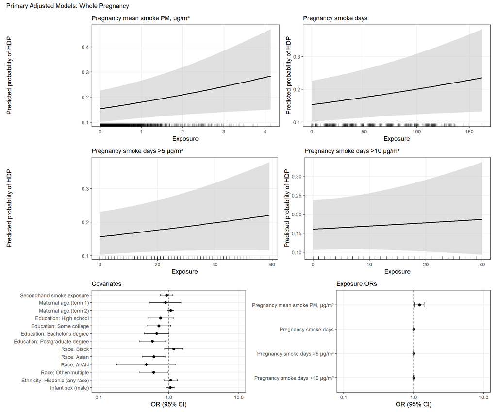

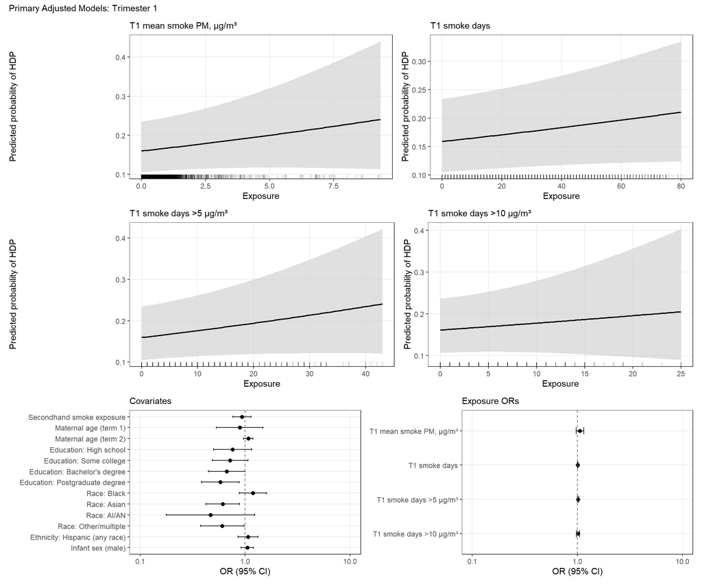

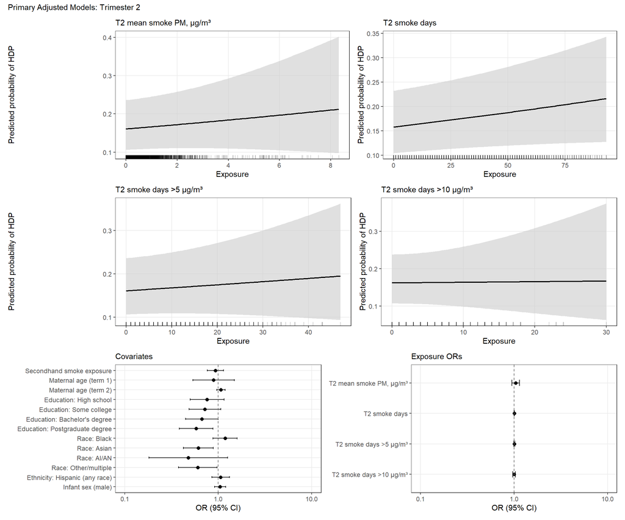

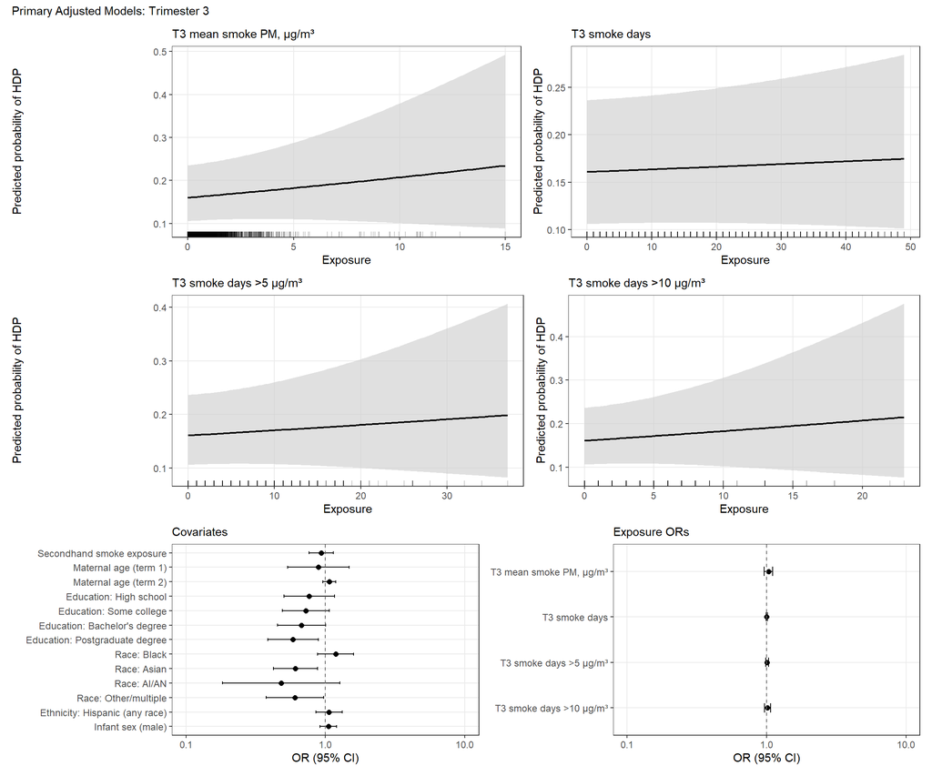

## 1.2 Fully Adjusted

From AP: “Extended models will be additionally adjusted for covariates selected based on availability of harmonized variables across cohorts, including household size-adjusted income (or neighborhood deprivation index), maternal pre-pregnancy BMI, history of chronic hypertension, history of pre-eclampsia, pre-pregnancy diabetes, prenatal smoking.”

- Model: Same parameters as primary adjusted model for exposure, outcome, cohort random intercept, handling missing data, and model optimization.
- Covariates: Maternal age (splined), secular trend (year splines), census macro region, tobacco use, alcohol consumption, tract-level poverty, pre-pregnancy BMI, birthing parent educational attainment, parity, race/ethnicity, infant sex

Extended Adjusted Model: preg_smoke_days

| Term | OR | 95% CI Low | 95% CI High | P-value |
| --- | --- | --- | --- | --- |
| Intercept | 0.088 | 0.040 | 0.190 | 0.0000 |
| preg_smoke_days (exposure) | 0.999 | 0.993 | 1.004 | 0.5741 |
| Secondhand smoke exposure | 0.922 | 0.747 | 1.140 | 0.4534 |
| Maternal age (term 1) | 0.798 | 0.473 | 1.346 | 0.3973 |
| Maternal age (term 2) | 1.036 | 0.930 | 1.153 | 0.5226 |
| Year (term 1) | 1.093 | 0.643 | 1.857 | 0.7421 |
| Year (term 2) | 1.162 | 0.627 | 2.154 | 0.6333 |
| Year (term 3) | 1.190 | 0.661 | 2.141 | 0.5616 |
| Smoking | 0.934 | 0.667 | 1.308 | 0.6908 |
| Alcohol consumption | 1.040 | 0.843 | 1.282 | 0.7128 |
| Spring conception | 1.070 | 0.862 | 1.328 | 0.5398 |
| Summer conception | 1.043 | 0.856 | 1.270 | 0.6784 |
| Winter conception | 1.024 | 0.824 | 1.272 | 0.8302 |
| Midwest | 1.057 | 0.858 | 1.302 | 0.6042 |
| South | 1.091 | 0.877 | 1.358 | 0.4355 |
| West | 1.111 | 0.913 | 1.353 | 0.2925 |
| Tract-level poverty | 0.998 | 0.992 | 1.004 | 0.5771 |
| BMI: Normal weight | 1.322 | 0.731 | 2.391 | 0.3559 |
| BMI: Overweight | 1.911 | 1.036 | 3.525 | 0.0382 |
| BMI: Obese | 3.894 | 2.133 | 7.109 | 0.0000 |
| Education: High school | 0.742 | 0.485 | 1.133 | 0.1669 |
| Education: Some college | 0.717 | 0.484 | 1.064 | 0.0986 |
| Education: Bachelor’s degree | 0.752 | 0.501 | 1.129 | 0.1698 |
| Education: Postgraduate degree | 0.686 | 0.450 | 1.044 | 0.0787 |
| Race: Black | 1.071 | 0.790 | 1.452 | 0.6592 |
| Race: Asian | 0.662 | 0.457 | 0.959 | 0.0293 |
| Race: AI/AN | 0.489 | 0.182 | 1.317 | 0.1559 |
| Race: Other/multiple | 0.569 | 0.351 | 0.923 | 0.0223 |
| Ethnicity: Hispanic (any race) | 0.923 | 0.734 | 1.160 | 0.4903 |
| Infant sex (male) | 1.047 | 0.911 | 1.203 | 0.5184 |

Extended Adjusted Model: T1_smoke_days

| Term | OR | 95% CI Low | 95% CI High | P-value |
| --- | --- | --- | --- | --- |
| Intercept | 0.086 | 0.040 | 0.186 | 0.0000 |
| T1_smoke_days (exposure) | 1.000 | 0.993 | 1.008 | 0.9271 |
| Secondhand smoke exposure | 0.922 | 0.746 | 1.139 | 0.4500 |
| Maternal age (term 1) | 0.800 | 0.475 | 1.349 | 0.4025 |
| Maternal age (term 2) | 1.037 | 0.931 | 1.154 | 0.5113 |
| Year (term 1) | 1.166 | 0.707 | 1.922 | 0.5471 |
| Year (term 2) | 1.188 | 0.644 | 2.189 | 0.5811 |
| Year (term 3) | 1.094 | 0.637 | 1.881 | 0.7436 |
| Smoking | 0.934 | 0.667 | 1.308 | 0.6892 |
| Alcohol consumption | 1.039 | 0.843 | 1.282 | 0.7167 |
| Spring conception | 1.046 | 0.846 | 1.293 | 0.6763 |
| Summer conception | 1.033 | 0.824 | 1.295 | 0.7799 |
| Winter conception | 1.005 | 0.817 | 1.236 | 0.9636 |
| Midwest | 1.055 | 0.856 | 1.300 | 0.6139 |
| South | 1.091 | 0.876 | 1.357 | 0.4369 |
| West | 1.112 | 0.913 | 1.354 | 0.2904 |
| Tract-level poverty | 0.998 | 0.992 | 1.004 | 0.5636 |
| BMI: Normal weight | 1.323 | 0.732 | 2.394 | 0.3535 |
| BMI: Overweight | 1.911 | 1.036 | 3.524 | 0.0383 |
| BMI: Obese | 3.899 | 2.136 | 7.116 | 0.0000 |
| Education: High school | 0.741 | 0.485 | 1.132 | 0.1649 |
| Education: Some college | 0.716 | 0.483 | 1.062 | 0.0965 |
| Education: Bachelor’s degree | 0.750 | 0.500 | 1.125 | 0.1646 |
| Education: Postgraduate degree | 0.683 | 0.448 | 1.041 | 0.0761 |
| Race: Black | 1.072 | 0.790 | 1.453 | 0.6566 |
| Race: Asian | 0.664 | 0.458 | 0.962 | 0.0304 |
| Race: AI/AN | 0.489 | 0.182 | 1.319 | 0.1565 |
| Race: Other/multiple | 0.571 | 0.352 | 0.925 | 0.0229 |
| Ethnicity: Hispanic (any race) | 0.928 | 0.738 | 1.165 | 0.5180 |
| Infant sex (male) | 1.047 | 0.911 | 1.203 | 0.5215 |

Extended Adjusted Model: T2_smoke_days

| Term | OR | 95% CI Low | 95% CI High | P-value |
| --- | --- | --- | --- | --- |
| Intercept | 0.086 | 0.040 | 0.185 | 0.0000 |
| T2_smoke_days (exposure) | 1.001 | 0.994 | 1.007 | 0.8300 |
| Secondhand smoke exposure | 0.922 | 0.746 | 1.139 | 0.4509 |
| Maternal age (term 1) | 0.801 | 0.475 | 1.350 | 0.4039 |
| Maternal age (term 2) | 1.037 | 0.931 | 1.154 | 0.5096 |
| Year (term 1) | 1.175 | 0.713 | 1.935 | 0.5272 |
| Year (term 2) | 1.192 | 0.646 | 2.200 | 0.5747 |
| Year (term 3) | 1.085 | 0.633 | 1.859 | 0.7677 |
| Smoking | 0.934 | 0.667 | 1.308 | 0.6912 |
| Alcohol consumption | 1.039 | 0.843 | 1.282 | 0.7161 |
| Spring conception | 1.035 | 0.818 | 1.311 | 0.7722 |
| Summer conception | 1.039 | 0.853 | 1.264 | 0.7056 |
| Winter conception | 0.996 | 0.798 | 1.243 | 0.9699 |
| Midwest | 1.055 | 0.857 | 1.300 | 0.6125 |
| South | 1.091 | 0.877 | 1.358 | 0.4344 |
| West | 1.112 | 0.914 | 1.354 | 0.2895 |
| Tract-level poverty | 0.998 | 0.992 | 1.004 | 0.5621 |
| BMI: Normal weight | 1.325 | 0.733 | 2.397 | 0.3512 |
| BMI: Overweight | 1.913 | 1.037 | 3.528 | 0.0378 |
| BMI: Obese | 3.903 | 2.139 | 7.124 | 0.0000 |
| Education: High school | 0.740 | 0.484 | 1.131 | 0.1639 |
| Education: Some college | 0.715 | 0.482 | 1.060 | 0.0952 |
| Education: Bachelor’s degree | 0.749 | 0.499 | 1.124 | 0.1628 |
| Education: Postgraduate degree | 0.682 | 0.448 | 1.040 | 0.0753 |
| Race: Black | 1.071 | 0.790 | 1.453 | 0.6585 |
| Race: Asian | 0.664 | 0.458 | 0.962 | 0.0305 |
| Race: AI/AN | 0.490 | 0.182 | 1.320 | 0.1574 |
| Race: Other/multiple | 0.571 | 0.352 | 0.925 | 0.0229 |
| Ethnicity: Hispanic (any race) | 0.928 | 0.739 | 1.166 | 0.5201 |
| Infant sex (male) | 1.046 | 0.911 | 1.203 | 0.5223 |

Extended Adjusted Model: T3_smoke_days

| Term | OR | 95% CI Low | 95% CI High | P-value |
| --- | --- | --- | --- | --- |
| Intercept | 0.086 | 0.040 | 0.187 | 0.0000 |
| T3_smoke_days (exposure) | 0.999 | 0.988 | 1.010 | 0.8821 |
| Secondhand smoke exposure | 0.922 | 0.746 | 1.139 | 0.4512 |
| Maternal age (term 1) | 0.799 | 0.474 | 1.348 | 0.4010 |
| Maternal age (term 2) | 1.037 | 0.931 | 1.154 | 0.5115 |
| Year (term 1) | 1.155 | 0.707 | 1.886 | 0.5656 |
| Year (term 2) | 1.183 | 0.642 | 2.182 | 0.5896 |
| Year (term 3) | 1.109 | 0.654 | 1.880 | 0.7019 |
| Smoking | 0.934 | 0.667 | 1.309 | 0.6911 |
| Alcohol consumption | 1.040 | 0.843 | 1.282 | 0.7148 |
| Spring conception | 1.045 | 0.846 | 1.290 | 0.6856 |
| Summer conception | 1.033 | 0.841 | 1.270 | 0.7561 |
| Winter conception | 1.009 | 0.813 | 1.253 | 0.9346 |
| Midwest | 1.055 | 0.857 | 1.300 | 0.6128 |
| South | 1.091 | 0.876 | 1.357 | 0.4372 |
| West | 1.112 | 0.913 | 1.354 | 0.2902 |
| Tract-level poverty | 0.998 | 0.992 | 1.004 | 0.5648 |
| BMI: Normal weight | 1.323 | 0.732 | 2.394 | 0.3535 |
| BMI: Overweight | 1.911 | 1.036 | 3.525 | 0.0382 |
| BMI: Obese | 3.899 | 2.136 | 7.116 | 0.0000 |
| Education: High school | 0.741 | 0.485 | 1.132 | 0.1650 |
| Education: Some college | 0.716 | 0.483 | 1.062 | 0.0964 |
| Education: Bachelor’s degree | 0.750 | 0.500 | 1.125 | 0.1646 |
| Education: Postgraduate degree | 0.683 | 0.449 | 1.041 | 0.0761 |
| Race: Black | 1.071 | 0.790 | 1.453 | 0.6570 |
| Race: Asian | 0.664 | 0.458 | 0.962 | 0.0303 |
| Race: AI/AN | 0.489 | 0.181 | 1.319 | 0.1566 |
| Race: Other/multiple | 0.571 | 0.352 | 0.925 | 0.0228 |
| Ethnicity: Hispanic (any race) | 0.927 | 0.738 | 1.164 | 0.5133 |
| Infant sex (male) | 1.046 | 0.911 | 1.203 | 0.5221 |

Extended Adjusted Model: preg_smoke_days_over5

| Term | OR | 95% CI Low | 95% CI High | P-value |
| --- | --- | --- | --- | --- |
| Intercept | 0.086 | 0.040 | 0.185 | 0.0000 |
| preg_smoke_days_over5 (exposure) | 1.000 | 0.989 | 1.012 | 0.9355 |
| Secondhand smoke exposure | 0.922 | 0.746 | 1.139 | 0.4501 |
| Maternal age (term 1) | 0.801 | 0.475 | 1.350 | 0.4043 |
| Maternal age (term 2) | 1.037 | 0.931 | 1.154 | 0.5121 |
| Year (term 1) | 1.164 | 0.709 | 1.912 | 0.5473 |
| Year (term 2) | 1.188 | 0.644 | 2.189 | 0.5817 |
| Year (term 3) | 1.096 | 0.642 | 1.871 | 0.7356 |
| Smoking | 0.934 | 0.667 | 1.308 | 0.6903 |
| Alcohol consumption | 1.039 | 0.843 | 1.282 | 0.7162 |
| Spring conception | 1.047 | 0.850 | 1.290 | 0.6657 |
| Summer conception | 1.038 | 0.853 | 1.263 | 0.7113 |
| Winter conception | 1.003 | 0.813 | 1.236 | 0.9797 |
| Midwest | 1.055 | 0.857 | 1.300 | 0.6125 |
| South | 1.091 | 0.877 | 1.357 | 0.4357 |
| West | 1.112 | 0.913 | 1.354 | 0.2905 |
| Tract-level poverty | 0.998 | 0.992 | 1.004 | 0.5646 |
| BMI: Normal weight | 1.324 | 0.732 | 2.394 | 0.3526 |
| BMI: Overweight | 1.911 | 1.037 | 3.524 | 0.0380 |
| BMI: Obese | 3.900 | 2.138 | 7.116 | 0.0000 |
| Education: High school | 0.740 | 0.484 | 1.132 | 0.1647 |
| Education: Some college | 0.716 | 0.482 | 1.062 | 0.0963 |
| Education: Bachelor’s degree | 0.750 | 0.499 | 1.125 | 0.1642 |
| Education: Postgraduate degree | 0.683 | 0.448 | 1.041 | 0.0761 |
| Race: Black | 1.071 | 0.790 | 1.453 | 0.6579 |
| Race: Asian | 0.664 | 0.458 | 0.962 | 0.0303 |
| Race: AI/AN | 0.490 | 0.182 | 1.320 | 0.1574 |
| Race: Other/multiple | 0.571 | 0.352 | 0.926 | 0.0230 |
| Ethnicity: Hispanic (any race) | 0.927 | 0.738 | 1.165 | 0.5176 |
| Infant sex (male) | 1.047 | 0.911 | 1.203 | 0.5192 |

Extended Adjusted Model: T1_smoke_days_over5

| Term | OR | 95% CI Low | 95% CI High | P-value |
| --- | --- | --- | --- | --- |
| Intercept | 0.086 | 0.040 | 0.185 | 0.0000 |
| T1_smoke_days_over5 (exposure) | 1.007 | 0.988 | 1.025 | 0.4844 |
| Secondhand smoke exposure | 0.921 | 0.745 | 1.138 | 0.4458 |
| Maternal age (term 1) | 0.802 | 0.476 | 1.352 | 0.4077 |
| Maternal age (term 2) | 1.037 | 0.932 | 1.155 | 0.5055 |
| Year (term 1) | 1.178 | 0.723 | 1.921 | 0.5109 |
| Year (term 2) | 1.187 | 0.645 | 2.187 | 0.5814 |
| Year (term 3) | 1.080 | 0.639 | 1.826 | 0.7732 |
| Smoking | 0.935 | 0.668 | 1.309 | 0.6939 |
| Alcohol consumption | 1.040 | 0.843 | 1.282 | 0.7152 |
| Spring conception | 1.037 | 0.842 | 1.275 | 0.7346 |
| Summer conception | 1.012 | 0.820 | 1.248 | 0.9148 |
| Winter conception | 1.007 | 0.819 | 1.238 | 0.9446 |
| Midwest | 1.055 | 0.856 | 1.299 | 0.6177 |
| South | 1.089 | 0.875 | 1.355 | 0.4457 |
| West | 1.112 | 0.913 | 1.354 | 0.2903 |
| Tract-level poverty | 0.998 | 0.992 | 1.004 | 0.5617 |
| BMI: Normal weight | 1.325 | 0.733 | 2.396 | 0.3516 |
| BMI: Overweight | 1.909 | 1.035 | 3.520 | 0.0385 |
| BMI: Obese | 3.902 | 2.138 | 7.119 | 0.0000 |
| Education: High school | 0.740 | 0.484 | 1.132 | 0.1646 |
| Education: Some college | 0.716 | 0.483 | 1.062 | 0.0964 |
| Education: Bachelor’s degree | 0.749 | 0.499 | 1.125 | 0.1634 |
| Education: Postgraduate degree | 0.682 | 0.448 | 1.040 | 0.0751 |
| Race: Black | 1.072 | 0.791 | 1.455 | 0.6532 |
| Race: Asian | 0.665 | 0.459 | 0.964 | 0.0312 |
| Race: AI/AN | 0.488 | 0.181 | 1.315 | 0.1548 |
| Race: Other/multiple | 0.573 | 0.354 | 0.929 | 0.0240 |
| Ethnicity: Hispanic (any race) | 0.930 | 0.740 | 1.168 | 0.5304 |
| Infant sex (male) | 1.047 | 0.911 | 1.203 | 0.5186 |

Extended Adjusted Model: T2_smoke_days_over5

| Term | OR | 95% CI Low | 95% CI High | P-value |
| --- | --- | --- | --- | --- |
| Intercept | 0.086 | 0.040 | 0.186 | 0.0000 |
| T2_smoke_days_over5 (exposure) | 0.997 | 0.980 | 1.015 | 0.7773 |
| Secondhand smoke exposure | 0.922 | 0.746 | 1.139 | 0.4505 |
| Maternal age (term 1) | 0.799 | 0.474 | 1.347 | 0.3998 |
| Maternal age (term 2) | 1.036 | 0.931 | 1.154 | 0.5160 |
| Year (term 1) | 1.150 | 0.704 | 1.877 | 0.5765 |
| Year (term 2) | 1.183 | 0.641 | 2.181 | 0.5907 |
| Year (term 3) | 1.113 | 0.658 | 1.883 | 0.6888 |
| Smoking | 0.934 | 0.667 | 1.308 | 0.6904 |
| Alcohol consumption | 1.039 | 0.843 | 1.281 | 0.7189 |
| Spring conception | 1.062 | 0.851 | 1.325 | 0.5963 |
| Summer conception | 1.039 | 0.853 | 1.264 | 0.7056 |
| Winter conception | 1.012 | 0.818 | 1.253 | 0.9118 |
| Midwest | 1.055 | 0.856 | 1.300 | 0.6141 |
| South | 1.090 | 0.876 | 1.357 | 0.4378 |
| West | 1.112 | 0.913 | 1.353 | 0.2916 |
| Tract-level poverty | 0.998 | 0.992 | 1.004 | 0.5657 |
| BMI: Normal weight | 1.323 | 0.731 | 2.393 | 0.3541 |
| BMI: Overweight | 1.910 | 1.036 | 3.522 | 0.0384 |
| BMI: Obese | 3.897 | 2.135 | 7.113 | 0.0000 |
| Education: High school | 0.741 | 0.485 | 1.133 | 0.1668 |
| Education: Some college | 0.717 | 0.483 | 1.064 | 0.0987 |
| Education: Bachelor’s degree | 0.752 | 0.500 | 1.129 | 0.1686 |
| Education: Postgraduate degree | 0.685 | 0.449 | 1.044 | 0.0785 |
| Race: Black | 1.072 | 0.790 | 1.454 | 0.6553 |
| Race: Asian | 0.663 | 0.458 | 0.961 | 0.0300 |
| Race: AI/AN | 0.490 | 0.182 | 1.319 | 0.1567 |
| Race: Other/multiple | 0.571 | 0.352 | 0.925 | 0.0227 |
| Ethnicity: Hispanic (any race) | 0.927 | 0.738 | 1.164 | 0.5133 |
| Infant sex (male) | 1.047 | 0.911 | 1.203 | 0.5190 |

Extended Adjusted Model: T3_smoke_days_over5

| Term | OR | 95% CI Low | 95% CI High | P-value |
| --- | --- | --- | --- | --- |
| Intercept | 0.085 | 0.039 | 0.184 | 0.0000 |
| T3_smoke_days_over5 (exposure) | 1.006 | 0.979 | 1.033 | 0.6898 |
| Secondhand smoke exposure | 0.921 | 0.745 | 1.139 | 0.4475 |
| Maternal age (term 1) | 0.803 | 0.476 | 1.354 | 0.4104 |
| Maternal age (term 2) | 1.036 | 0.930 | 1.153 | 0.5207 |
| Year (term 1) | 1.169 | 0.717 | 1.906 | 0.5304 |
| Year (term 2) | 1.191 | 0.646 | 2.196 | 0.5746 |
| Year (term 3) | 1.091 | 0.646 | 1.842 | 0.7441 |
| Smoking | 0.934 | 0.667 | 1.308 | 0.6884 |
| Alcohol consumption | 1.039 | 0.843 | 1.282 | 0.7160 |
| Spring conception | 1.055 | 0.858 | 1.298 | 0.6095 |
| Summer conception | 1.047 | 0.857 | 1.279 | 0.6546 |
| Winter conception | 0.997 | 0.808 | 1.229 | 0.9744 |
| Midwest | 1.055 | 0.856 | 1.300 | 0.6147 |
| South | 1.092 | 0.877 | 1.359 | 0.4309 |
| West | 1.111 | 0.913 | 1.353 | 0.2938 |
| Tract-level poverty | 0.998 | 0.992 | 1.004 | 0.5636 |
| BMI: Normal weight | 1.324 | 0.732 | 2.394 | 0.3526 |
| BMI: Overweight | 1.912 | 1.037 | 3.524 | 0.0379 |
| BMI: Obese | 3.901 | 2.138 | 7.117 | 0.0000 |
| Education: High school | 0.741 | 0.485 | 1.133 | 0.1665 |
| Education: Some college | 0.716 | 0.483 | 1.063 | 0.0972 |
| Education: Bachelor’s degree | 0.751 | 0.500 | 1.127 | 0.1666 |
| Education: Postgraduate degree | 0.684 | 0.449 | 1.043 | 0.0776 |
| Race: Black | 1.071 | 0.790 | 1.453 | 0.6589 |
| Race: Asian | 0.663 | 0.458 | 0.961 | 0.0299 |
| Race: AI/AN | 0.493 | 0.183 | 1.328 | 0.1606 |
| Race: Other/multiple | 0.571 | 0.352 | 0.925 | 0.0230 |
| Ethnicity: Hispanic (any race) | 0.928 | 0.739 | 1.166 | 0.5214 |
| Infant sex (male) | 1.047 | 0.911 | 1.204 | 0.5147 |

Extended Adjusted Model: preg_smoke_days_over10

| Term | OR | 95% CI Low | 95% CI High | P-value |
| --- | --- | --- | --- | --- |
| Intercept | 0.086 | 0.040 | 0.187 | 0.0000 |
| preg_smoke_days_over10 (exposure) | 0.993 | 0.971 | 1.016 | 0.5424 |
| Secondhand smoke exposure | 0.923 | 0.747 | 1.141 | 0.4559 |
| Maternal age (term 1) | 0.798 | 0.473 | 1.346 | 0.3974 |
| Maternal age (term 2) | 1.036 | 0.931 | 1.154 | 0.5167 |
| Year (term 1) | 1.158 | 0.712 | 1.883 | 0.5539 |
| Year (term 2) | 1.170 | 0.634 | 2.160 | 0.6148 |
| Year (term 3) | 1.109 | 0.658 | 1.867 | 0.6978 |
| Smoking | 0.933 | 0.666 | 1.307 | 0.6873 |
| Alcohol consumption | 1.038 | 0.842 | 1.280 | 0.7257 |
| Spring conception | 1.057 | 0.860 | 1.300 | 0.5968 |
| Summer conception | 1.041 | 0.855 | 1.268 | 0.6865 |
| Winter conception | 1.012 | 0.822 | 1.245 | 0.9131 |
| Midwest | 1.055 | 0.856 | 1.300 | 0.6136 |
| South | 1.091 | 0.877 | 1.358 | 0.4353 |
| West | 1.112 | 0.914 | 1.354 | 0.2885 |
| Tract-level poverty | 0.998 | 0.992 | 1.004 | 0.5655 |
| BMI: Normal weight | 1.324 | 0.732 | 2.395 | 0.3527 |
| BMI: Overweight | 1.912 | 1.037 | 3.527 | 0.0380 |
| BMI: Obese | 3.901 | 2.138 | 7.121 | 0.0000 |
| Education: High school | 0.740 | 0.484 | 1.132 | 0.1649 |
| Education: Some college | 0.717 | 0.483 | 1.063 | 0.0980 |
| Education: Bachelor’s degree | 0.751 | 0.501 | 1.128 | 0.1678 |
| Education: Postgraduate degree | 0.685 | 0.449 | 1.043 | 0.0778 |
| Race: Black | 1.073 | 0.791 | 1.455 | 0.6505 |
| Race: Asian | 0.663 | 0.458 | 0.960 | 0.0297 |
| Race: AI/AN | 0.489 | 0.182 | 1.318 | 0.1565 |
| Race: Other/multiple | 0.570 | 0.352 | 0.924 | 0.0225 |
| Ethnicity: Hispanic (any race) | 0.926 | 0.738 | 1.164 | 0.5108 |
| Infant sex (male) | 1.046 | 0.910 | 1.202 | 0.5262 |

Extended Adjusted Model: T1_smoke_days_over10

| Term | OR | 95% CI Low | 95% CI High | P-value |
| --- | --- | --- | --- | --- |
| Intercept | 0.086 | 0.040 | 0.186 | 0.0000 |
| T1_smoke_days_over10 (exposure) | 0.999 | 0.964 | 1.036 | 0.9566 |
| Secondhand smoke exposure | 0.922 | 0.746 | 1.139 | 0.4507 |
| Maternal age (term 1) | 0.800 | 0.474 | 1.349 | 0.4021 |
| Maternal age (term 2) | 1.036 | 0.931 | 1.154 | 0.5129 |
| Year (term 1) | 1.160 | 0.713 | 1.887 | 0.5501 |
| Year (term 2) | 1.186 | 0.643 | 2.185 | 0.5849 |
| Year (term 3) | 1.102 | 0.654 | 1.856 | 0.7151 |
| Smoking | 0.934 | 0.667 | 1.308 | 0.6895 |
| Alcohol consumption | 1.039 | 0.843 | 1.281 | 0.7169 |
| Spring conception | 1.049 | 0.855 | 1.288 | 0.6455 |
| Summer conception | 1.040 | 0.849 | 1.273 | 0.7060 |
| Winter conception | 1.004 | 0.817 | 1.234 | 0.9687 |
| Midwest | 1.055 | 0.857 | 1.300 | 0.6120 |
| South | 1.091 | 0.877 | 1.358 | 0.4350 |
| West | 1.112 | 0.913 | 1.354 | 0.2905 |
| Tract-level poverty | 0.998 | 0.992 | 1.004 | 0.5650 |
| BMI: Normal weight | 1.323 | 0.732 | 2.393 | 0.3532 |
| BMI: Overweight | 1.911 | 1.037 | 3.524 | 0.0381 |
| BMI: Obese | 3.899 | 2.137 | 7.115 | 0.0000 |
| Education: High school | 0.740 | 0.485 | 1.132 | 0.1649 |
| Education: Some college | 0.716 | 0.483 | 1.062 | 0.0965 |
| Education: Bachelor’s degree | 0.750 | 0.500 | 1.126 | 0.1648 |
| Education: Postgraduate degree | 0.683 | 0.449 | 1.041 | 0.0764 |
| Race: Black | 1.071 | 0.790 | 1.453 | 0.6571 |
| Race: Asian | 0.664 | 0.458 | 0.961 | 0.0301 |
| Race: AI/AN | 0.490 | 0.182 | 1.321 | 0.1575 |
| Race: Other/multiple | 0.571 | 0.352 | 0.925 | 0.0228 |
| Ethnicity: Hispanic (any race) | 0.927 | 0.738 | 1.164 | 0.5146 |
| Infant sex (male) | 1.047 | 0.911 | 1.203 | 0.5204 |

Extended Adjusted Model: T2_smoke_days_over10

| Term | OR | 95% CI Low | 95% CI High | P-value |
| --- | --- | --- | --- | --- |
| Intercept | 0.086 | 0.040 | 0.185 | 0.0000 |
| T2_smoke_days_over10 (exposure) | 0.989 | 0.954 | 1.024 | 0.5259 |
| Secondhand smoke exposure | 0.922 | 0.746 | 1.140 | 0.4521 |
| Maternal age (term 1) | 0.799 | 0.474 | 1.348 | 0.4008 |
| Maternal age (term 2) | 1.036 | 0.930 | 1.153 | 0.5219 |
| Year (term 1) | 1.158 | 0.712 | 1.884 | 0.5541 |
| Year (term 2) | 1.174 | 0.637 | 2.165 | 0.6069 |
| Year (term 3) | 1.106 | 0.657 | 1.863 | 0.7038 |
| Smoking | 0.935 | 0.667 | 1.309 | 0.6928 |
| Alcohol consumption | 1.039 | 0.842 | 1.281 | 0.7208 |
| Spring conception | 1.068 | 0.864 | 1.320 | 0.5435 |
| Summer conception | 1.039 | 0.854 | 1.264 | 0.7041 |
| Winter conception | 1.014 | 0.823 | 1.250 | 0.8926 |
| Midwest | 1.054 | 0.856 | 1.299 | 0.6190 |
| South | 1.090 | 0.875 | 1.356 | 0.4423 |
| West | 1.111 | 0.913 | 1.353 | 0.2922 |
| Tract-level poverty | 0.998 | 0.992 | 1.004 | 0.5670 |
| BMI: Normal weight | 1.325 | 0.732 | 2.396 | 0.3521 |
| BMI: Overweight | 1.910 | 1.035 | 3.523 | 0.0384 |
| BMI: Obese | 3.901 | 2.137 | 7.120 | 0.0000 |
| Education: High school | 0.742 | 0.485 | 1.134 | 0.1682 |
| Education: Some college | 0.718 | 0.484 | 1.066 | 0.1002 |
| Education: Bachelor’s degree | 0.753 | 0.502 | 1.131 | 0.1716 |
| Education: Postgraduate degree | 0.687 | 0.450 | 1.046 | 0.0803 |
| Race: Black | 1.072 | 0.791 | 1.454 | 0.6539 |
| Race: Asian | 0.663 | 0.458 | 0.961 | 0.0300 |
| Race: AI/AN | 0.489 | 0.182 | 1.317 | 0.1559 |
| Race: Other/multiple | 0.571 | 0.352 | 0.925 | 0.0228 |
| Ethnicity: Hispanic (any race) | 0.927 | 0.738 | 1.165 | 0.5163 |
| Infant sex (male) | 1.047 | 0.911 | 1.203 | 0.5202 |

Extended Adjusted Model: T3_smoke_days_over10

| Term | OR | 95% CI Low | 95% CI High | P-value |
| --- | --- | --- | --- | --- |
| Intercept | 0.085 | 0.039 | 0.185 | 0.0000 |
| T3_smoke_days_over10 (exposure) | 1.011 | 0.962 | 1.063 | 0.6654 |
| Secondhand smoke exposure | 0.921 | 0.745 | 1.138 | 0.4456 |
| Maternal age (term 1) | 0.801 | 0.475 | 1.351 | 0.4054 |
| Maternal age (term 2) | 1.036 | 0.931 | 1.153 | 0.5190 |
| Year (term 1) | 1.160 | 0.713 | 1.888 | 0.5493 |
| Year (term 2) | 1.191 | 0.646 | 2.196 | 0.5754 |
| Year (term 3) | 1.100 | 0.653 | 1.853 | 0.7208 |
| Smoking | 0.933 | 0.666 | 1.307 | 0.6864 |
| Alcohol consumption | 1.040 | 0.843 | 1.282 | 0.7125 |
| Spring conception | 1.052 | 0.857 | 1.291 | 0.6271 |
| Summer conception | 1.043 | 0.856 | 1.271 | 0.6765 |
| Winter conception | 0.998 | 0.810 | 1.230 | 0.9871 |
| Midwest | 1.055 | 0.856 | 1.300 | 0.6149 |
| South | 1.092 | 0.877 | 1.358 | 0.4324 |
| West | 1.111 | 0.912 | 1.352 | 0.2953 |
| Tract-level poverty | 0.998 | 0.992 | 1.004 | 0.5647 |
| BMI: Normal weight | 1.323 | 0.732 | 2.392 | 0.3537 |
| BMI: Overweight | 1.911 | 1.037 | 3.522 | 0.0381 |
| BMI: Obese | 3.899 | 2.137 | 7.114 | 0.0000 |
| Education: High school | 0.742 | 0.486 | 1.135 | 0.1688 |
| Education: Some college | 0.717 | 0.483 | 1.064 | 0.0981 |
| Education: Bachelor’s degree | 0.751 | 0.501 | 1.128 | 0.1681 |
| Education: Postgraduate degree | 0.685 | 0.449 | 1.044 | 0.0781 |
| Race: Black | 1.071 | 0.789 | 1.452 | 0.6601 |
| Race: Asian | 0.663 | 0.458 | 0.961 | 0.0300 |
| Race: AI/AN | 0.493 | 0.183 | 1.327 | 0.1602 |
| Race: Other/multiple | 0.571 | 0.352 | 0.925 | 0.0229 |
| Ethnicity: Hispanic (any race) | 0.927 | 0.738 | 1.164 | 0.5140 |
| Infant sex (male) | 1.047 | 0.911 | 1.203 | 0.5187 |

Extended Adjusted Model: preg_smokePM_mean

| Term | OR | 95% CI Low | 95% CI High | P-value |
| --- | --- | --- | --- | --- |
| Intercept | 0.085 | 0.039 | 0.183 | 0.0000 |
| preg_smokePM_mean (exposure) | 1.057 | 0.876 | 1.277 | 0.5613 |
| Secondhand smoke exposure | 0.922 | 0.746 | 1.139 | 0.4491 |
| Maternal age (term 1) | 0.804 | 0.477 | 1.355 | 0.4123 |
| Maternal age (term 2) | 1.037 | 0.931 | 1.154 | 0.5101 |
| Year (term 1) | 1.192 | 0.726 | 1.955 | 0.4875 |
| Year (term 2) | 1.202 | 0.651 | 2.217 | 0.5567 |
| Year (term 3) | 1.063 | 0.622 | 1.814 | 0.8237 |
| Smoking | 0.934 | 0.667 | 1.309 | 0.6923 |
| Alcohol consumption | 1.040 | 0.844 | 1.283 | 0.7109 |
| Spring conception | 1.038 | 0.843 | 1.278 | 0.7247 |
| Summer conception | 1.036 | 0.851 | 1.261 | 0.7231 |
| Winter conception | 0.994 | 0.807 | 1.225 | 0.9571 |
| Midwest | 1.055 | 0.856 | 1.300 | 0.6151 |
| South | 1.090 | 0.876 | 1.357 | 0.4376 |
| West | 1.111 | 0.913 | 1.353 | 0.2927 |
| Tract-level poverty | 0.998 | 0.992 | 1.004 | 0.5610 |
| BMI: Normal weight | 1.325 | 0.733 | 2.395 | 0.3509 |
| BMI: Overweight | 1.911 | 1.037 | 3.523 | 0.0379 |
| BMI: Obese | 3.901 | 2.139 | 7.116 | 0.0000 |
| Education: High school | 0.740 | 0.485 | 1.132 | 0.1649 |
| Education: Some college | 0.715 | 0.482 | 1.061 | 0.0954 |
| Education: Bachelor’s degree | 0.748 | 0.499 | 1.123 | 0.1619 |
| Education: Postgraduate degree | 0.682 | 0.447 | 1.039 | 0.0748 |
| Race: Black | 1.071 | 0.790 | 1.453 | 0.6577 |
| Race: Asian | 0.665 | 0.459 | 0.963 | 0.0308 |
| Race: AI/AN | 0.489 | 0.182 | 1.318 | 0.1565 |
| Race: Other/multiple | 0.572 | 0.353 | 0.928 | 0.0236 |
| Ethnicity: Hispanic (any race) | 0.930 | 0.740 | 1.168 | 0.5310 |
| Infant sex (male) | 1.047 | 0.911 | 1.204 | 0.5136 |

Extended Adjusted Model: T1_smokePM_mean

| Term | OR | 95% CI Low | 95% CI High | P-value |
| --- | --- | --- | --- | --- |
| Intercept | 0.086 | 0.040 | 0.185 | 0.0000 |
| T1_smokePM_mean (exposure) | 1.009 | 0.916 | 1.111 | 0.8577 |
| Secondhand smoke exposure | 0.922 | 0.746 | 1.139 | 0.4500 |
| Maternal age (term 1) | 0.800 | 0.475 | 1.349 | 0.4035 |
| Maternal age (term 2) | 1.037 | 0.931 | 1.154 | 0.5102 |
| Year (term 1) | 1.165 | 0.714 | 1.900 | 0.5410 |
| Year (term 2) | 1.188 | 0.645 | 2.189 | 0.5805 |
| Year (term 3) | 1.095 | 0.648 | 1.853 | 0.7338 |
| Smoking | 0.934 | 0.667 | 1.308 | 0.6908 |
| Alcohol consumption | 1.039 | 0.843 | 1.282 | 0.7160 |
| Spring conception | 1.046 | 0.851 | 1.286 | 0.6694 |
| Summer conception | 1.032 | 0.838 | 1.271 | 0.7686 |
| Winter conception | 1.005 | 0.818 | 1.236 | 0.9618 |
| Midwest | 1.055 | 0.856 | 1.300 | 0.6143 |
| South | 1.090 | 0.876 | 1.357 | 0.4377 |
| West | 1.112 | 0.913 | 1.354 | 0.2899 |
| Tract-level poverty | 0.998 | 0.992 | 1.004 | 0.5639 |
| BMI: Normal weight | 1.324 | 0.732 | 2.394 | 0.3526 |
| BMI: Overweight | 1.910 | 1.036 | 3.523 | 0.0382 |
| BMI: Obese | 3.900 | 2.137 | 7.116 | 0.0000 |
| Education: High school | 0.741 | 0.485 | 1.132 | 0.1650 |
| Education: Some college | 0.716 | 0.483 | 1.062 | 0.0966 |
| Education: Bachelor’s degree | 0.750 | 0.500 | 1.125 | 0.1645 |
| Education: Postgraduate degree | 0.683 | 0.448 | 1.041 | 0.0760 |
| Race: Black | 1.072 | 0.790 | 1.453 | 0.6566 |
| Race: Asian | 0.664 | 0.458 | 0.962 | 0.0305 |
| Race: AI/AN | 0.489 | 0.181 | 1.318 | 0.1563 |
| Race: Other/multiple | 0.571 | 0.352 | 0.926 | 0.0232 |
| Ethnicity: Hispanic (any race) | 0.928 | 0.739 | 1.165 | 0.5196 |
| Infant sex (male) | 1.047 | 0.911 | 1.203 | 0.5195 |

Extended Adjusted Model: T2_smokePM_mean

| Term | OR | 95% CI Low | 95% CI High | P-value |
| --- | --- | --- | --- | --- |
| Intercept | 0.086 | 0.040 | 0.186 | 0.0000 |
| T2_smokePM_mean (exposure) | 0.982 | 0.878 | 1.099 | 0.7523 |
| Secondhand smoke exposure | 0.922 | 0.746 | 1.139 | 0.4498 |
| Maternal age (term 1) | 0.799 | 0.474 | 1.347 | 0.3991 |
| Maternal age (term 2) | 1.036 | 0.931 | 1.154 | 0.5155 |
| Year (term 1) | 1.149 | 0.704 | 1.875 | 0.5780 |
| Year (term 2) | 1.180 | 0.640 | 2.178 | 0.5956 |
| Year (term 3) | 1.115 | 0.659 | 1.887 | 0.6844 |
| Smoking | 0.934 | 0.667 | 1.308 | 0.6899 |
| Alcohol consumption | 1.039 | 0.843 | 1.281 | 0.7197 |
| Spring conception | 1.062 | 0.853 | 1.322 | 0.5900 |
| Summer conception | 1.038 | 0.853 | 1.264 | 0.7074 |
| Winter conception | 1.012 | 0.818 | 1.252 | 0.9095 |
| Midwest | 1.055 | 0.856 | 1.300 | 0.6158 |
| South | 1.090 | 0.876 | 1.357 | 0.4388 |
| West | 1.112 | 0.913 | 1.354 | 0.2902 |
| Tract-level poverty | 0.998 | 0.992 | 1.004 | 0.5670 |
| BMI: Normal weight | 1.323 | 0.731 | 2.393 | 0.3542 |
| BMI: Overweight | 1.910 | 1.035 | 3.522 | 0.0384 |
| BMI: Obese | 3.897 | 2.135 | 7.112 | 0.0000 |
| Education: High school | 0.741 | 0.485 | 1.133 | 0.1662 |
| Education: Some college | 0.717 | 0.483 | 1.064 | 0.0986 |
| Education: Bachelor’s degree | 0.752 | 0.501 | 1.128 | 0.1684 |
| Education: Postgraduate degree | 0.685 | 0.449 | 1.044 | 0.0784 |
| Race: Black | 1.072 | 0.790 | 1.453 | 0.6567 |
| Race: Asian | 0.663 | 0.458 | 0.961 | 0.0300 |
| Race: AI/AN | 0.490 | 0.182 | 1.319 | 0.1569 |
| Race: Other/multiple | 0.570 | 0.352 | 0.924 | 0.0227 |
| Ethnicity: Hispanic (any race) | 0.927 | 0.738 | 1.164 | 0.5124 |
| Infant sex (male) | 1.047 | 0.911 | 1.203 | 0.5191 |

Extended Adjusted Model: T3_smokePM_mean

| Term | OR | 95% CI Low | 95% CI High | P-value |
| --- | --- | --- | --- | --- |
| Intercept | 0.085 | 0.039 | 0.184 | 0.0000 |
| T3_smokePM_mean (exposure) | 1.020 | 0.942 | 1.104 | 0.6282 |
| Secondhand smoke exposure | 0.921 | 0.746 | 1.139 | 0.4477 |
| Maternal age (term 1) | 0.802 | 0.476 | 1.352 | 0.4080 |
| Maternal age (term 2) | 1.036 | 0.930 | 1.153 | 0.5200 |
| Year (term 1) | 1.169 | 0.718 | 1.904 | 0.5297 |
| Year (term 2) | 1.193 | 0.647 | 2.200 | 0.5711 |
| Year (term 3) | 1.090 | 0.646 | 1.838 | 0.7476 |
| Smoking | 0.933 | 0.666 | 1.307 | 0.6847 |
| Alcohol consumption | 1.040 | 0.843 | 1.282 | 0.7150 |
| Spring conception | 1.056 | 0.859 | 1.299 | 0.6028 |
| Summer conception | 1.048 | 0.858 | 1.279 | 0.6475 |
| Winter conception | 0.995 | 0.806 | 1.228 | 0.9617 |
| Midwest | 1.055 | 0.856 | 1.300 | 0.6146 |
| South | 1.091 | 0.877 | 1.358 | 0.4326 |
| West | 1.111 | 0.912 | 1.352 | 0.2957 |
| Tract-level poverty | 0.998 | 0.992 | 1.004 | 0.5645 |
| BMI: Normal weight | 1.323 | 0.732 | 2.392 | 0.3539 |
| BMI: Overweight | 1.911 | 1.037 | 3.521 | 0.0380 |
| BMI: Obese | 3.899 | 2.137 | 7.113 | 0.0000 |
| Education: High school | 0.742 | 0.485 | 1.135 | 0.1683 |
| Education: Some college | 0.717 | 0.483 | 1.064 | 0.0981 |
| Education: Bachelor’s degree | 0.752 | 0.501 | 1.128 | 0.1681 |
| Education: Postgraduate degree | 0.685 | 0.449 | 1.043 | 0.0780 |
| Race: Black | 1.071 | 0.789 | 1.452 | 0.6601 |
| Race: Asian | 0.663 | 0.458 | 0.961 | 0.0298 |
| Race: AI/AN | 0.493 | 0.183 | 1.329 | 0.1610 |
| Race: Other/multiple | 0.571 | 0.352 | 0.925 | 0.0229 |
| Ethnicity: Hispanic (any race) | 0.928 | 0.739 | 1.165 | 0.5185 |
| Infant sex (male) | 1.047 | 0.911 | 1.204 | 0.5151 |

### 1.2.1 Plot

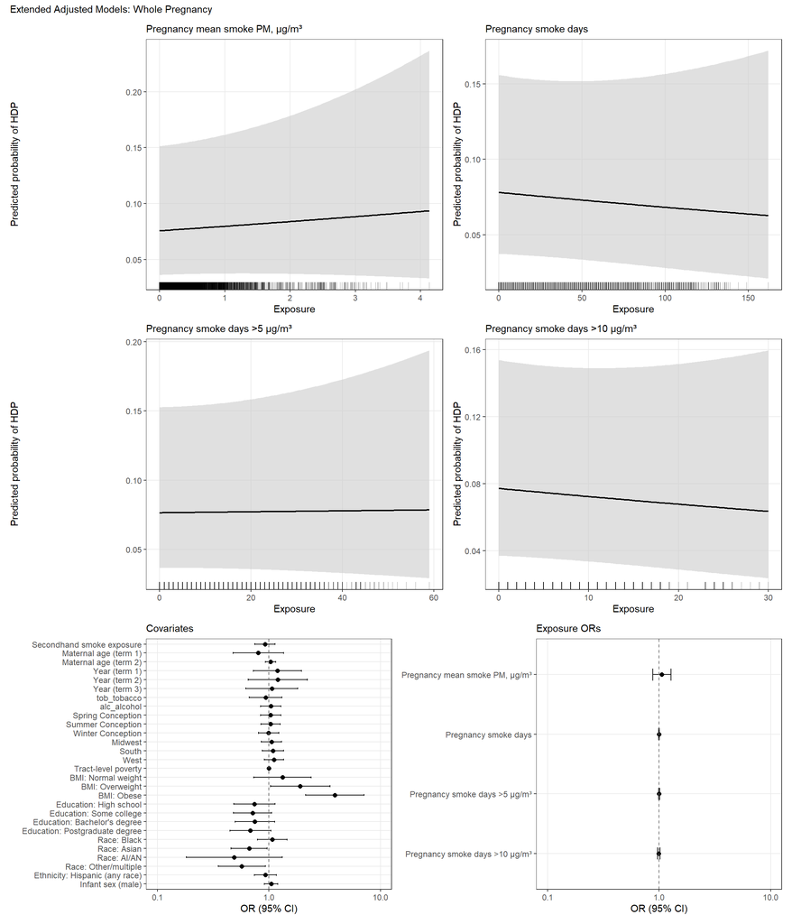

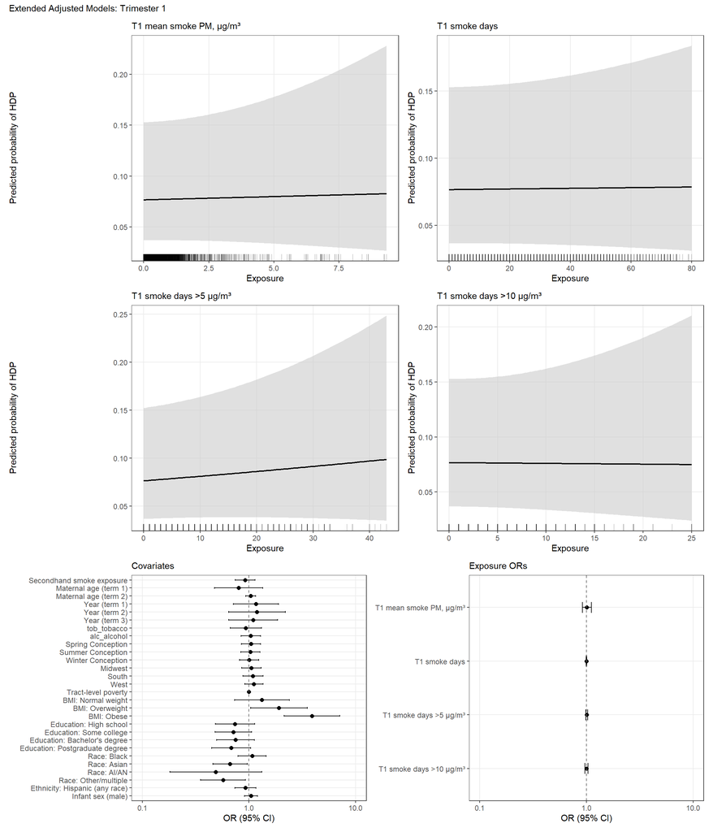

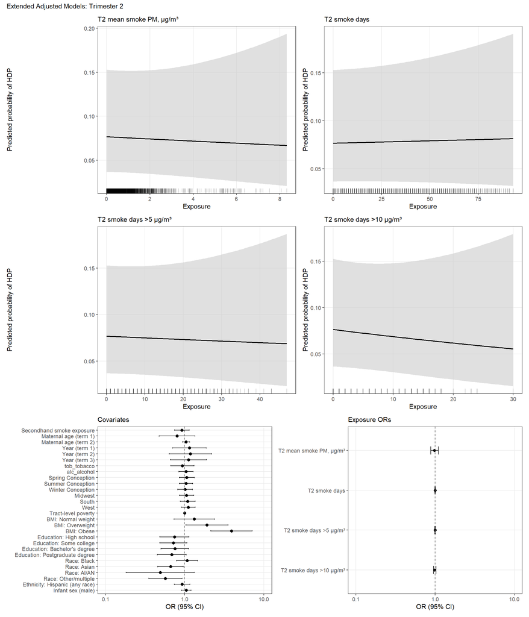

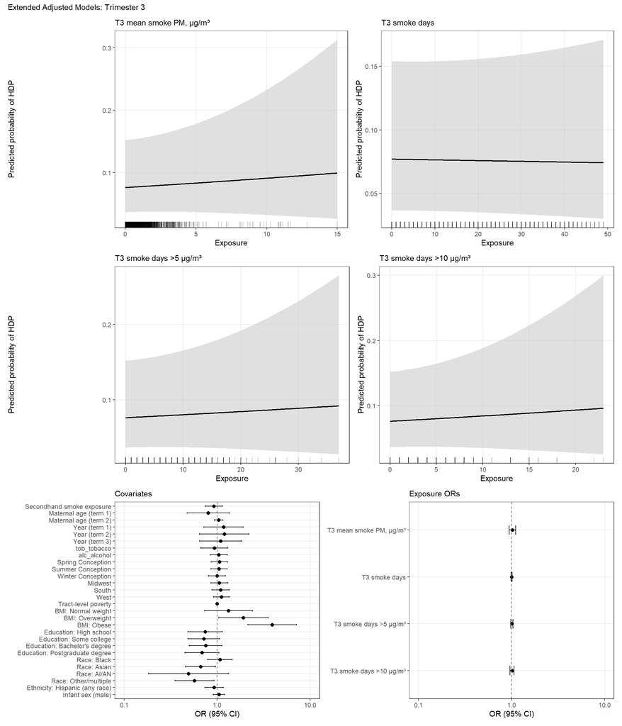

# 2 Effect Measure Modification

## 2.1 Mean PM X Infant Sex

- n male = 4139
- n female = 3933

Effect Measure Modification by Infant Sex: Mean Smoke PM

|  | Exposure | Stratum | OR | 95% CI Low | 95% CI High | P-value | P-heterogeneity |
| --- | --- | --- | --- | --- | --- | --- | --- |
| preg_smokePM_mean…1 | Pregnancy mean smoke PM, μg/m³ | Male | 1.070 | 0.818 | 1.398 | 0.6221 | 0.8970 |
| preg_smokePM_mean…2 | Pregnancy mean smoke PM, μg/m³ | Female | 1.043 | 0.802 | 1.357 | 0.7512 | 0.8970 |
| T1_smokePM_mean…3 | T1 mean smoke PM, μg/m³ | Male | 1.058 | 0.925 | 1.209 | 0.4103 | 0.3721 |
| T1_smokePM_mean…4 | T1 mean smoke PM, μg/m³ | Female | 0.967 | 0.837 | 1.117 | 0.6497 | 0.3721 |
| T2_smokePM_mean…5 | T2 mean smoke PM, μg/m³ | Male | 0.949 | 0.808 | 1.114 | 0.5197 | 0.5444 |
| T2_smokePM_mean…6 | T2 mean smoke PM, μg/m³ | Female | 1.017 | 0.869 | 1.191 | 0.8338 | 0.5444 |
| T3_smokePM_mean…7 | T3 mean smoke PM, μg/m³ | Male | 1.029 | 0.924 | 1.146 | 0.6067 | 0.7417 |
| T3_smokePM_mean…8 | T3 mean smoke PM, μg/m³ | Female | 1.002 | 0.892 | 1.124 | 0.9767 | 0.7417 |

### 2.1.1 Plot

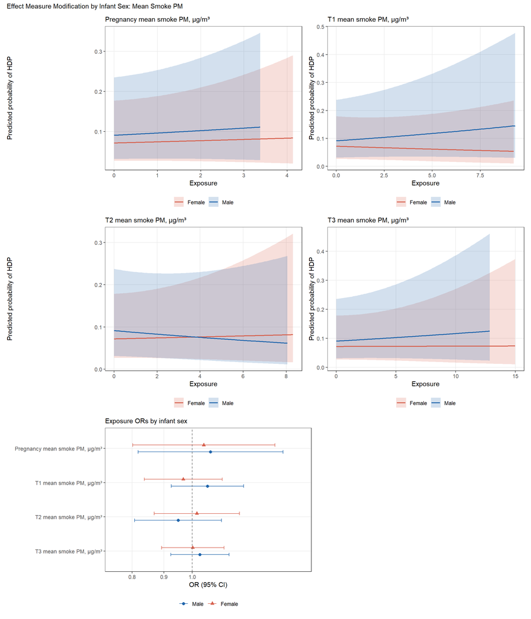

## 2.2 Mean PM X Census Region

- n Northeast = 3161
- n Midwest = 1658
- n South = 1254
- n West = 2000

Effect Measure Modification by Census Region: Mean Smoke PM

|  | Exposure | Stratum | OR | 95% CI Low | 95% CI High | P-value | P-heterogeneity |
| --- | --- | --- | --- | --- | --- | --- | --- |
| preg_smokePM_mean…1 | Pregnancy mean smoke PM, μg/m³ | Northeast | 1.238 | 0.861 | 1.780 | 0.2481 | 0.6615 |
| preg_smokePM_mean…2 | Pregnancy mean smoke PM, μg/m³ | Midwest | 0.910 | 0.645 | 1.283 | 0.5890 | 0.6615 |
| preg_smokePM_mean…3 | Pregnancy mean smoke PM, μg/m³ | South | 1.142 | 0.720 | 1.810 | 0.5729 | 0.6615 |
| preg_smokePM_mean…4 | Pregnancy mean smoke PM, μg/m³ | West | 1.031 | 0.717 | 1.481 | 0.8709 | 0.6615 |
| T1_smokePM_mean…5 | T1 mean smoke PM, μg/m³ | Northeast | 1.103 | 0.927 | 1.313 | 0.2668 | 0.6114 |
| T1_smokePM_mean…6 | T1 mean smoke PM, μg/m³ | Midwest | 0.932 | 0.782 | 1.110 | 0.4266 | 0.6114 |
| T1_smokePM_mean…7 | T1 mean smoke PM, μg/m³ | South | 1.012 | 0.808 | 1.267 | 0.9176 | 0.6114 |
| T1_smokePM_mean…8 | T1 mean smoke PM, μg/m³ | West | 1.019 | 0.798 | 1.301 | 0.8823 | 0.6114 |
| T2_smokePM_mean…9 | T2 mean smoke PM, μg/m³ | Northeast | 1.016 | 0.821 | 1.256 | 0.8851 | 0.8913 |
| T2_smokePM_mean…10 | T2 mean smoke PM, μg/m³ | Midwest | 0.908 | 0.722 | 1.141 | 0.4061 | 0.8913 |
| T2_smokePM_mean…11 | T2 mean smoke PM, μg/m³ | South | 0.971 | 0.715 | 1.319 | 0.8527 | 0.8913 |
| T2_smokePM_mean…12 | T2 mean smoke PM, μg/m³ | West | 1.008 | 0.828 | 1.226 | 0.9396 | 0.8913 |
| T3_smokePM_mean…13 | T3 mean smoke PM, μg/m³ | Northeast | 1.062 | 0.897 | 1.257 | 0.4876 | 0.9228 |
| T3_smokePM_mean…14 | T3 mean smoke PM, μg/m³ | Midwest | 0.998 | 0.867 | 1.150 | 0.9807 | 0.9228 |
| T3_smokePM_mean…15 | T3 mean smoke PM, μg/m³ | South | 0.968 | 0.753 | 1.245 | 0.8008 | 0.9228 |
| T3_smokePM_mean…16 | T3 mean smoke PM, μg/m³ | West | 1.028 | 0.894 | 1.182 | 0.6991 | 0.9228 |

### 2.2.1 Plot

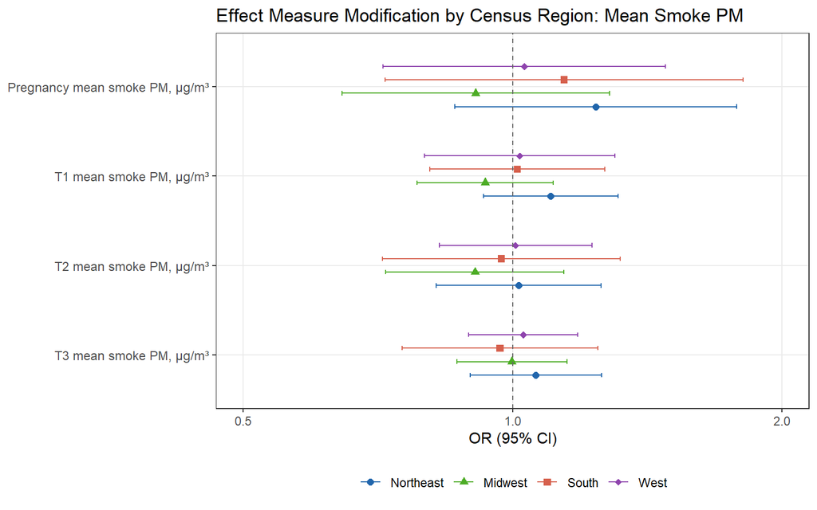